```python
#importing necessary libraries that will be using in my work
import pandas as pd
import numpy as np
import matplotlib.pyplot as plt
import seaborn as sns
from scipy.stats import ttest_ind
from statsmodels.formula.api import ols
import statsmodels.api as sm
from sklearn.utils import resample
from statsmodels.discrete.discrete_model import Probit
from statsmodels.tools import add_constant
from sklearn.ensemble import GradientBoostingClassifier, GradientBoostingRegressor
from sklearn.model_selection import cross_val_predict, KFold
import statsmodels.formula.api as smf
from sklearn.neighbors import KNeighborsRegressor
```

```python
#for removing warnings(mostly future) just to make our code looks good
import warnings
warnings.filterwarnings("ignore")
warnings.filterwarnings("ignore", category=DeprecationWarning)
```

# Part 1:

```python
# Loading dataset
file_path = 'dataset_v1.csv'
data = pd.read_csv(file_path)

# differntiating dataset into two group based on funding status
funded = data[data['funding_v1'] > 0]  # School ares receiving extra textbook funding
non_funded = data[data['funding_v1'] == 0]  # School are not receiving extra textbook funding

# Calculating mean differences for average_score_v1 and mathscore_v1 to use that in next part
mean_diff_avg_score = funded['average_score_v1'].mean() - non_funded['average_score_v1'].mean()
mean_diff_mathscore = funded['mathscore_v1'].mean() - non_funded['mathscore_v1'].mean()

# Performing t-tests for average_score_v1 and mathscore_v1 to check and interprating the results
ttest_avg_score = ttest_ind(funded['average_score_v1'], non_funded['average_score_v1'])
ttest_mathscore = ttest_ind(funded['mathscore_v1'], non_funded['mathscore_v1'])

print("Mean Difference in Average Score: ", mean_diff_avg_score)
print("Mean Difference in Math Score: ", mean_diff_mathscore)
print("\nT-test for Average Score:\nT-statistic: {}, P-value: {}".format(ttest_avg_score.statistic, ttest_avg_score.pvalue))
print("\nT-test for Math Score:\nT-statistic: {}, P-value: {}".format(ttest_mathscore.statistic, ttest_mathscore.pvalue))
```

```
Mean Difference in Average Score:  -0.8300676493856509
Mean Difference in Math Score:  -0.7591853979725924

T-test for Average Score:
T-statistic: -47.23201942989658, P-value: 0.0

T-test for Math Score:
T-statistic: -56.971051916824514, P-value: 0.0
```

### Interpreteration:

The negative mean differences indicate that schools receiving extra textbook funding and on average and score lower in both overall average scores and math scores compared to schools not receiving extra funds. The highly significant p-values suggest that these differences are statistically significant and not due to random chance.

### Assumptions:

We assume each schools outcome is independent of others. This could be violated if schools within same district or area influence each other. The assumption that hold variances of outcomes are equal in both groups and if funding automaticlaly goes to schools in more challenging. The t-test assumes that differences between groups are normally distributed.

### Potential Violations:

If schools receiving funding are systematically different from those that do not lower initial scores or socio-economic status so observed differences might not lonely be depending to funding. Some Other factors such as teacher quality and student to teacher ratios or curriculum differences and might drive the observed differences rather than textbook funding itself.

# Part2:

```python
# Preprocessing data: Convert funding to binary and ensure covariates are formated so it can easily be usuable in the work
data['funding_binary'] = (data['funding_v1'] > 0).astype(int)

# OLS estimation
def estimate_ols(data):
    formula = 'outcome_variable ~ funding_binary + pct_wh_v1 + pct_hi_v1 + pct_aa_v1 + fte_t_v1 + fte_a_v1 + fte_p_v1 + yrs_teach_v1'
    model = ols(formula=formula, data=data).fit()
    return model.params['funding_binary']

# manually Bootstrap function for standard errors
def bootstrap_se(data, n_bootstrap=1000):
    estimates = []
    for _ in range(n_bootstrap):
        sample = resample(data)
        estimate = estimate_ols(sample)
        estimates.append(estimate)
    return np.std(estimates, ddof=1)

# Estimate ATE for average_score_v1
data['outcome_variable'] = data['average_score_v1']
ate_average_score = estimate_ols(data)
se_average_score = bootstrap_se(data)

# Estimate ATE for mathscore_v1
data['outcome_variable'] = data['mathscore_v1']
ate_mathscore = estimate_ols(data)
se_mathscore = bootstrap_se(data)

print(f"ATE (average score): {ate_average_score}, Bootstrapped SE: {se_average_score}")
print(f"ATE (math score): {ate_mathscore}, Bootstrapped SE: {se_mathscore}")
```

```
ATE (average score): -0.6381689977938557, Bootstrapped SE: 0.019724725020150546
ATE (math score): -0.6834309494831505, Bootstrapped SE: 0.015663207342044107
```

### Ate hinges on assumptions:

Linearity, No omitted variable bias, Random sampling, Independence of observations

# Part3:

Including variable percentfrl, which represents percentage of students eligible for free or reduced lunch, in a regression model could control for socioeconomic status (SES). This could reduce observed negative impact of extra textbook funding on average scores and as part of this effect might be due to SES rather than funding itself. So coefficient for extra funding would likely decrease to more accurately isolating its impact.

# Part4:

```python
# Define the OLS model with interactions for CATE estimation
formula_cate = 'average_score_v1 ~ funding_binary + yrs_teach_v1 + frl_bin_v1 + funding_binary:yrs_teach_v1 + funding_binary:frl_bin_v1'
model_cate = ols(formula=formula_cate, data=data).fit()

# Bootstrap function adapted for calculating standard errors for this model
def bootstrap_cate_ols(data, formula, n_bootstraps=1000):
    coefficients = []
    for _ in range(n_bootstraps):
        sample = resample(data)
        model = ols(formula=formula, data=sample).fit()
        coefficients.append(model.params[['funding_binary:yrs_teach_v1', 'funding_binary:frl_bin_v1']].values)
    coefficients = np.array(coefficients)
    standard_errors = coefficients.std(axis=0)
    return standard_errors

# Calculating bootstrapped standard error
bootstrap_se_cate = bootstrap_cate_ols(data, formula_cate)

# Extract model coefficients and standard errors for visualization and interpretation
cate_coefficients = model_cate.params[['funding_binary:yrs_teach_v1', 'funding_binary:frl_bin_v1']]
cate_se = bootstrap_se_cate

# T-statistics and p-values for interaction terms
t_stats = cate_coefficients / cate_se
p_values = model_cate.pvalues[['funding_binary:yrs_teach_v1', 'funding_binary:frl_bin_v1']]

cate_coefficients, cate_se, t_stats, p_values
```

```
(funding_binary:yrs_teach_v1    0.049442
 funding_binary:frl_bin_v1      0.256733
 dtype: float64,
 array([0.02734977, 0.05317628]),
 funding_binary:yrs_teach_v1    1.807772
 funding_binary:frl_bin_v1      4.827971
 dtype: float64,
 funding_binary:yrs_teach_v1    5.503215e-02
 funding_binary:frl_bin_v1      2.748250e-08
 dtype: float64)
```

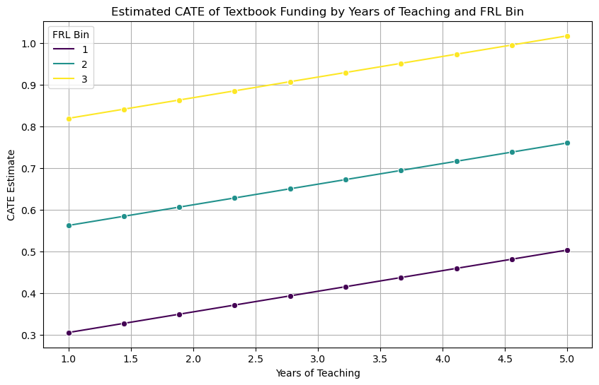

```python
yrs_teach_vals = np.linspace(data['yrs_teach_v1'].min(), data['yrs_teach_v1'].max(), 10)
frl_bin_vals = data['frl_bin_v1'].unique()

# Prepare data for plotting and visualization
plot_data = []
for yrs in yrs_teach_vals:
    for frl_bin in frl_bin_vals:
        # Adjusted to only include relevant interaction terms.
        cate_estimate = cate_coefficients['funding_binary:yrs_teach_v1'] * yrs + \
                        cate_coefficients['funding_binary:frl_bin_v1'] * frl_bin
        plot_data.append([yrs, frl_bin, cate_estimate])

plot_df = pd.DataFrame(plot_data, columns=['Years of Teaching', 'FRL Bin', 'CATE Estimate'])

# Plotting
plt.figure(figsize=(10, 6))
sns.lineplot(data=plot_df, x='Years of Teaching', y='CATE Estimate', hue='FRL Bin', palette='viridis', marker='o')
plt.title('Estimated CATE of Textbook Funding by Years of Teaching and FRL Bin')
plt.xlabel('Years of Teaching')
plt.ylabel('CATE Estimate')
plt.legend(title='FRL Bin')
plt.grid(True)
plt.show()
```

# Part 5:

```python
X = data[['pct_wh_v1', 'pct_hi_v1', 'pct_aa_v1', 'fte_t_v1', 'fte_a_v1', 'fte_p_v1', 'yrs_teach_v1']]
X = add_constant(X)
y = data['funding_binary']

# Fitting a Probit model to estimate propensity scores
probit_model = Probit(y, X).fit()

# Predict propensity scores
data['propensity_score'] = probit_model.predict(X)
# Calculate weights for IPW
data['weights'] = np.where(data['funding_binary'] == 1,
                           1 / data['propensity_score'],
                           1 / (1 - data['propensity_score']))

# Calculate the IPW estimate for average treatment effect
ate_ipw = np.average(data['average_score_v1'], weights=data['weights'])


def bootstrap_ipw(data, n_bootstraps=1000):
    ipw_estimates = []
    for _ in range(n_bootstraps):
        # Resampling
        sample = data.sample(n=len(data), replace=True)
        # Calculate IPW estimate for the bootstrap sample
        sample_weight = np.where(sample['funding_binary'] == 1,
                                 1 / sample['propensity_score'],
                                 1 / (1 - sample['propensity_score']))
        ipw_estimate = np.average(sample['average_score_v1'], weights=sample_weight)
        ipw_estimates.append(ipw_estimate)
    return np.std(ipw_estimates), ipw_estimates  # Return standard error and all bootstrap estimates

# Calculate bootstrapped standard error and all estimates
bootstrap_se, bootstrap_estimates = bootstrap_ipw(data)

# Calculate p-value assuming a normal distribution of bootstrap estimates
from scipy.stats import norm
p_value = 2 * norm.cdf(-np.abs(ate_ipw) / bootstrap_se)
```

```
Optimization terminated successfully.
         Current function value: 0.518991
         Iterations 6
```

# Part 6:

```python
import numpy as np
import pandas as pd
import statsmodels.api as sm
from statsmodels.discrete.discrete_model import Probit
from sklearn.utils import resample

def doubly_robust_estimation(data, outcome, treatment, covariates, n_bootstraps=100):
    # Step 1: Estimate propensity scores using a probit model defiing in pdf
    X = sm.add_constant(data[covariates])
    probit_model = Probit(data[treatment], X).fit(disp=0)
    data['propensity_score'] = probit_model.predict(X)

    # Step 2: Estimate outcome using linear regression including treatment as a covariate(some or all)
    X_outcome = sm.add_constant(data[covariates + [treatment]])
    outcome_model = sm.OLS(data[outcome], X_outcome).fit()

    # Step 3: Calculate ATE using the doubly robust approach
    def calculate_ate(row):
        treated_df = pd.DataFrame([np.append(row[covariates], 1)], columns=covariates + [treatment])
        control_df = pd.DataFrame([np.append(row[covariates], 0)], columns=covariates + [treatment])

        # Add a constant for prediction
        treated_df = sm.add_constant(treated_df, has_constant='add')
        control_df = sm.add_constant(control_df, has_constant='add')

        # Predicting a outcomes
        predicted_outcome_treated = outcome_model.predict(treated_df)[0]
        predicted_outcome_control = outcome_model.predict(control_df)[0]

        # Calculating weights
        weight_treated = row[treatment] / row['propensity_score']
        weight_control = (1 - row[treatment]) / (1 - row['propensity_score'])

        # Doubly robust estimate
        dr_estimate = (row[outcome] - predicted_outcome_control if row[treatment] == 0 else row[outcome] - predicted_outcome_treated) + \
                      (predicted_outcome_treated - predicted_outcome_control)
        return dr_estimate * (weight_treated if row[treatment] == 1 else weight_control)

    data['dr_estimate'] = data.apply(calculate_ate, axis=1)
    ate_estimate = data['dr_estimate'].mean()

    # Bootstrap for standard errors
    bootstrap_ates = []
    for _ in range(n_bootstraps):
        sample = resample(data)
        sample_ate = sample['dr_estimate'].mean()
        bootstrap_ates.append(sample_ate)

    se = np.std(bootstrap_ates)

    return ate_estimate, se

ate_estimate, se = doubly_robust_estimation(data, outcome, treatment, covariates, n_bootstraps=100)
print(f"Estimated ATE: {ate_estimate}, Standard Error: {se}")
```

```
Estimated ATE: -3.2221426162258737, Standard Error: 0.5383035700951461
```

# Part7:

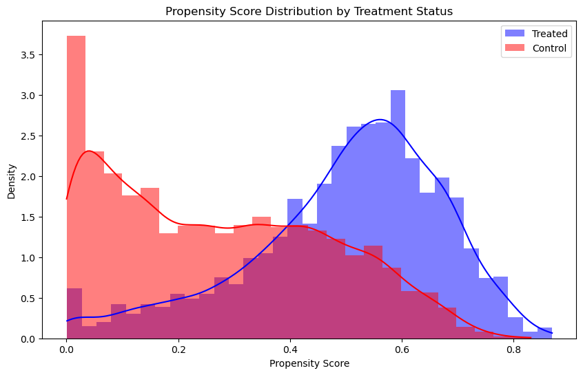

```python
plt.figure(figsize=(10, 6))
sns.histplot(data[data['funding_binary'] == 1]['propensity_score'], color='blue', kde=True, stat="density", linewidth=0, label='Treated')
sns.histplot(data[data['funding_binary'] == 0]['propensity_score'], color='red', kde=True, stat="density", linewidth=0, label='Control')
plt.title('Propensity Score Distribution by Treatment Status')
plt.xlabel('Propensity Score')
plt.ylabel('Density')
plt.legend()
plt.show()
```

### Results:

There appears to be a significant area where distributions of propensity scores for both treated and control groups overlap, which is a good indication that there is common support. This suggests that for a wide range of scores there are both treated and untreated subjects tht allowing for comparisons between similarly individuals.

The common support assumption appears to hold across a wide range of score distribution where there is substantial overlap between treated and control groups. However at the extremes and particularly at lower end of the propensity score range assumption does not hold because there is little to no overlap almost no individuals in treated group have very low scores and as indicated by red area without corresponding blue coverage.

# Part 8:

```python
outcome = 'average_score_v1'
treatment = 'funding_binary'
covariates = ['pct_wh_v1', 'pct_hi_v1', 'pct_aa_v1', 'fte_t_v1', 'fte_a_v1', 'fte_p_v1', 'yrs_teach_v1']

# Splitting data for cross-fitting
kf = KFold(n_splits=5, shuffle=True, random_state=42)

# Initializing models for score and outcome
propensity_model = GradientBoostingClassifier()
outcome_model = GradientBoostingRegressor()

# Predicting propensity scores using cross-validation
propensity_scores = cross_val_predict(propensity_model, data[covariates], data[treatment], cv=kf, method='predict_proba')[:, 1]

# Predicting outcomes using cross-validation
predicted_outcomes = cross_val_predict(outcome_model, data[covariates + [treatment]], data[outcome], cv=kf)

# Compute ATE using doubly robust formula
def compute_ate(row, predicted_outcomes):
    if row[treatment] == 1:
        return (row[outcome] - predicted_outcomes) / row['propensity_score']
    else:
        return (predicted_outcomes - row[outcome]) / (1 - row['propensity_score'])

# Add scores to DataFrame
data['propensity_score'] = propensity_scores

# Calculating ATE
ate = data.apply(lambda row: compute_ate(row, predicted_outcomes), axis=1).mean()

print(f"Estimated ATE: {ate}")
```

```
Estimated ATE: [-0.6321512  -0.63050159 -0.61537354 ... -0.59944678 -0.58582431
 -0.59788517]
```

### Results:

Compared to traditional models (like logit or probit for propensity score and linear models for outcome) and machine learning models can capture more complex relationships and interactions between covariates. This can potentially lead to better estimates of nuisance functions and especially in high dimensional settings where linear models might be misspecified. Regarding part 7, DML framework with cross-fitting can provide more reliable ATE estimates when there's overlap in covariate distributions between treatment and control groups. However it still subject to common support assumption—there must be sufficient overlap in covariate distributions for treatment effect to be identifiable.

# Part 9:

```python
# covariates all
all_covariates = [col for col in data.columns if col not in [outcome, treatment, 'propensity_score', 'dr_estimate']]

# Re-run the doubly robust estimation with all available covariates
ate_estimate_all_covariates, se_all_covariates = doubly_robust_estimation(data, outcome, treatment, all_covariates, n_bootstraps=100)

print(f"Estimated ATE using all covariates: {ate_estimate_all_covariates}, Standard Error: {se_all_covariates}")
```

```
Estimated ATE using all covariates: 6.5864525139402235e-12, Standard Error: 2.378399314878242e-14
```

### Interpretation and Discussion

#### Part 6:

The initial ATE estimate suggests that receiving extra textbook funding is associated with a significant decrease in average score outcome. The standard error indicates precision of this estimate and it suggests some variability but does not decrease overall conclusion that effect is different from zero.

#### Part 9:

Upon including all available covariates and ATE estimate badly changes to a value that is essentially zero. This suggests that once all factors included as covariates in analysis are controlled and there appears to be no visible effect of extra textbook funding on the average score. The extremely small standard error indicates high precision in this estimates and reinforcing conclusion that ATE is close to zero.

# Part 10:

```python
# Subsetting data for cutoff
data_rdd = data[(data['norm_v1'] >= -10) & (data['norm_v1'] <= 10)]

# Specifying and fitting regression model
model_rdd = smf.ols('average_score_v1 ~ funding_binary', data=data_rdd).fit()

# Finding estimated mean difference its standard error and t-statistic and its p-value
mean_difference = model_rdd.params['funding_binary']
std_error = model_rdd.bse['funding_binary']
t_statistic = model_rdd.tvalues['funding_binary']
p_value = model_rdd.pvalues['funding_binary']

print(f"Estimated mean difference: {mean_difference}")
print(f"Standard error: {std_error}")
print(f"T-statistic: {t_statistic}")
print(f"P-value: {p_value}")
```

```
Estimated mean difference: 0.23849090732437903
Standard error: 0.046204113874635605
T-statistic: 5.161681229759542
P-value: 2.784406327621857e-07
```

### Discussion:

The results tells that method of analysis significantly affects estimated impact of extra textbook funding. The RDD estimate is likely more reflective of True causal effect for schools near funding eligibility threshold and previous estimates may have been capturing other forms of bias or were reflecting a whole average treatment effect (ATE) that includes schools far from the cutoff

# Part 11:

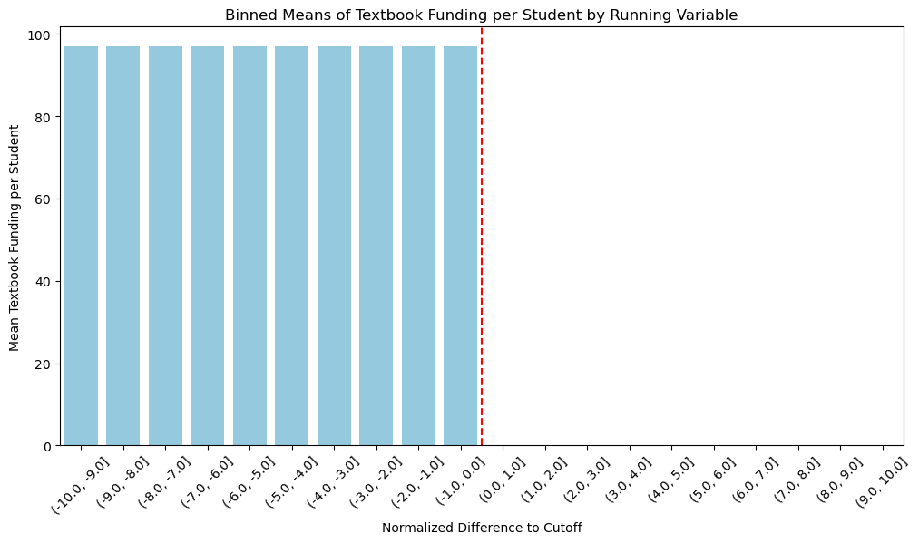

```python
# Binning data around cutoff without crossing 0
data_rdd['bin'] = pd.cut(data_rdd['norm_v1'], bins=np.linspace(-10, 10, num=21))

# Calculating mean funding per student in each bin
binned_means = data_rdd.groupby('bin')['funding_v1'].mean().reset_index()

# Plotting
plt.figure(figsize=(12, 6))
sns.barplot(x='bin', y='funding_v1', data=binned_means, color='skyblue')
plt.xticks(rotation=45)
plt.axvline(x=9.5, color='r', linestyle='--')
plt.xlabel('Normalized Difference to Cutoff')
plt.ylabel('Mean Textbook Funding per Student')
plt.title('Binned Means of Textbook Funding per Student by Running Variable')
plt.show()
```

### Discussion:

The design intends for a sharp RDD.

# Part 12:

[figure not shown]

```python
# Calculating mean average_score again for each bin now
binned_means_score = data_rdd.groupby('bin')['average_score_v1'].mean().reset_index()

# Plotting binned means of average_score
plt.figure(figsize=(12, 6))
sns.barplot(x='bin', y='average_score_v1', data=binned_means_score, color='lightgreen')
plt.xticks(rotation=45)
plt.axvline(x=9.5, color='r', linestyle='--')
plt.xlabel('Normalized Difference to Cutoff')
plt.ylabel('Mean Average Score')
plt.title('Binned Means of Average Score by Running Variable')
plt.show()
```

# Part 13:

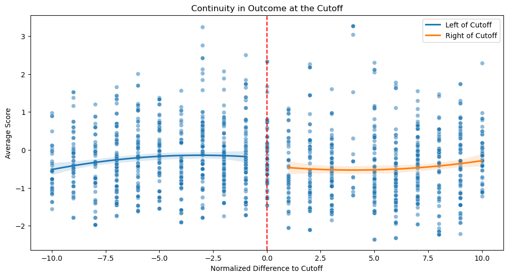

```python
import matplotlib.pyplot as plt
import seaborn as sns

# Scatter plot of the outcome
plt.figure(figsize=(12, 6))
sns.scatterplot(x='norm_v1', y='average_score_v1', data=data_rdd, alpha=0.5)

# Polynomial fit on either side of the cutoff
sns.regplot(x='norm_v1', y='average_score_v1', data=data_rdd[data_rdd['norm_v1'] < 0], scatter=False, order=2, label='Left of Cutoff')
sns.regplot(x='norm_v1', y='average_score_v1', data=data_rdd[data_rdd['norm_v1'] > 0], scatter=False, order=2, label='Right of Cutoff')

plt.axvline(x=0, color='red', linestyle='--') #cutted_off line
plt.xlabel('Normalized Difference to Cutoff')
plt.ylabel('Average Score')
plt.title('Continuity in Outcome at the Cutoff')
plt.legend()
plt.show()
```

### Discussion:

The plot seems to show a small discontinuity at cutoff point and blue and orange lines do not appear to connect seamlessly. Howeve whether this is a statistically significant discontinuity that can be confidently attributed to treatment effect requires a formal statistical test like RDD above.

# Part 14:

Checking for manipulation in the running variable is essential in (RDD) to ensure that assignment to treatment is not manipulated around cutoff point. Manipulation could occur if individuals or object intentionally manipulate their score to influence their likelihood of receiving treatment.

In case of Williams settlement which often involves educational funding or resources allocated based on academic performance metrics, manipulation in running variable may not be a significant concern for several reasons:

Legal Framework: The Williams settlement typically involves legal agreements to address educational inequalities, particularly in underprivileged areas. These settlements often come with strict legal oversight and enforcement mechanisms to ensure compliance with terms of the agreement. Educational authorities are bound by law to implement provisions of settlement fairly and impartially.

Transparency and Accountability: The terms of Williams settlement are usually transparent and publicly available and outlining specific criteria for funding allocation or resource distribution. Educational authorities are accountable to stakeholders including the public and advocacy groups ensuring that any allocation decisions are made transparently and in accordance with agreed-upon criteria.

Public Scrutiny: Educational funding and resource allocation decisions and especially those related to high-profile legal settlements like Williams often attract significant public scrutiny. Any suspected manipulation or unfair practices in assigning resources based on academic performance metrics would likely face public backlash and could lead to legal challenges.

Data Integrity and Monitoring: Educational authorities typically employ robust data collection, monitoring and auditing mechanisms to ensure tht integrity of academic performance metrics used in settlement. Any anomalies or irregularities in data that could indicate manipulation would be subject to investigation and correction.

Stakeholder Involvement: The implementation of Williams settlement often involves collaboration with various stakeholders and including educators and community members, advocacy groups. The involvement of diverse stakeholders helps to ensure that allocation decisions are fair equitable and aligned with objectives of settlement.

# Part 15:

```python
import statsmodels.api as sm

# Subsetting the data around the cutoff agian
data_rdd = data[(data['norm_v1'] >= -10) & (data['norm_v1'] <= 10)]

#polynomial terms
data_rdd['distance_linear'] = data_rdd['norm_v1']  # Linear term
data_rdd['distance_quad'] = data_rdd['norm_v1'] ** 2  # Quadratic term
data_rdd['distance_cubic'] = data_rdd['norm_v1'] ** 3  # Cubic term

# Model 1: Linear regression
X_linear = sm.add_constant(data_rdd[['funding_binary', 'distance_linear']])
model_linear = sm.OLS(data_rdd['average_score_v1'], X_linear).fit()
print("Linear Regression Results:")
print(model_linear.summary())

# Model 2: Quadratic regression
X_quad = sm.add_constant(data_rdd[['funding_binary', 'distance_linear', 'distance_quad']])
model_quad = sm.OLS(data_rdd['average_score_v1'], X_quad).fit()
print("\nQuadratic Regression Results:")
print(model_quad.summary())

# Model 3: Cubic regression
X_cubic = sm.add_constant(data_rdd[['funding_binary', 'distance_linear', 'distance_quad', 'distance_cubic']])
model_cubic = sm.OLS(data_rdd['average_score_v1'], X_cubic).fit()
print("\nCubic Regression Results:")
print(model_cubic.summary())
```

```
Linear Regression Results:
                            OLS Regression Results
==============================================================================
Dep. Variable:       average_score_v1   R-squared:                       0.024
Model:                            OLS   Adj. R-squared:                  0.022
Method:                 Least Squares   F-statistic:                     17.80
Date:                Sat, 09 Mar 2024   Prob (F-statistic):           2.30e-08
Time:                        17:01:33   Log-Likelihood:                -1882.4
No. Observations:                1462   AIC:                             3771.
Df Residuals:                    1459   BIC:                             3787.
Df Model:                           2
Covariance Type:            nonrobust
===================================================================================
                      coef    std err          t      P>|t|      [0.025      0.975]
-----------------------------------------------------------------------------------
const              -0.5923      0.056    -10.562      0.000      -0.702      -0.482
funding_binary      0.4771      0.093      5.150      0.000       0.295       0.659
distance_linear     0.0237      0.008      2.969      0.003       0.008       0.039
==============================================================================
Omnibus:                      115.341   Durbin-Watson:                   1.985
Prob(Omnibus):                  0.000   Jarque-Bera (JB):              155.466
Skew:                           0.657   Prob(JB):                     1.74e-34
Kurtosis:                       3.909   Cond. No.                         26.9
==============================================================================

Notes:
[1] Standard Errors assume that the covariance matrix of the errors is correctly specified.

Quadratic Regression Results:
                            OLS Regression Results
==============================================================================
Dep. Variable:       average_score_v1   R-squared:                       0.024
Model:                            OLS   Adj. R-squared:                  0.022
Method:                 Least Squares   F-statistic:                     12.01
Date:                Sat, 09 Mar 2024   Prob (F-statistic):           9.12e-08
Time:                        17:01:33   Log-Likelihood:                -1882.2
No. Observations:                1462   AIC:                             3772.
Df Residuals:                    1458   BIC:                             3794.
Df Model:                           3
Covariance Type:            nonrobust
```

[output cut: 33 more lines]

```
funding_binary      0.2745      0.123      2.232      0.026       0.033       0.516
distance_linear    -0.0190      0.019     -0.989      0.323      -0.057       0.019
distance_quad      -0.0008      0.001     -1.056      0.291      -0.002       0.001
distance_cubic      0.0005      0.000      2.425      0.015    8.77e-05       0.001
==============================================================================
Omnibus:                      117.337   Durbin-Watson:                   1.981
Prob(Omnibus):                  0.000   Jarque-Bera (JB):              160.256
Skew:                           0.659   Prob(JB):                     1.59e-35
Kurtosis:                       3.945   Cond. No.                     2.44e+03
==============================================================================

Notes:
[1] Standard Errors assume that the covariance matrix of the errors is correctly specified.
[2] The condition number is large, 2.44e+03. This might indicate that there are
strong multicollinearity or other numerical problems.
```

# Part 16:

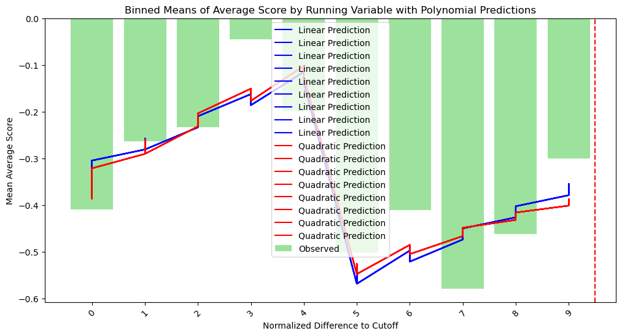

```python
num_bins = 10
data_rdd['bin'] = pd.cut(data_rdd['norm_v1'], bins=num_bins, labels=False)

data_rdd['norm_v1_squared'] = data_rdd['norm_v1'] ** 2

# Calculate predicted values using linear regression
data_rdd['linear_predicted_rdd'] = model_linear.predict(sm.add_constant(data_rdd[['funding_binary', 'norm_v1']]))

# Calculate predicted values using quadratic regression
data_rdd['quad_predicted_rdd'] = model_quad.predict(sm.add_constant(data_rdd[['funding_binary', 'norm_v1', 'norm_v1_squared']]))
# Merge predicted values with binned_means_score DataFrame, renaming columns in data_rdd first
# Rename columns in the data_rdd DataFrame before merging
data_rdd.rename(columns={'linear_predicted_rdd': 'linear_predicted', 'quad_predicted_rdd': 'quad_predicted'}, inplace=True)

# Merge predicted values with binned_means_score DataFrame
binned_means_score = binned_means_score.merge(data_rdd[['bin', 'linear_predicted', 'quad_predicted']],
                                              on='bin', how='inner')

# Plotting binned means of average_score by running variable
plt.figure(figsize=(12, 6))
sns.barplot(x='bin', y='average_score_v1', data=binned_means_score, color='lightgreen', label='Observed')
plt.plot(binned_means_score['bin'], binned_means_score['linear_predicted'], color='blue', label='Linear Prediction')
plt.plot(binned_means_score['bin'], binned_means_score['quad_predicted'], color='red', label='Quadratic Prediction')
plt.axvline(x=9.5, color='r', linestyle='--') # Assuming 20 bins, 0 is between the 10th and 11th bin
plt.xlabel('Normalized Difference to Cutoff')
plt.ylabel('Mean Average Score')
plt.title('Binned Means of Average Score by Running Variable with Polynomial Predictions')
plt.legend()
plt.xticks(rotation=45)
plt.show()
```

# Part 17:

```python
# Define bandwidths to test
bandwidths = [0.1, 0.5, 1.0]

# Results array
results = []

# Iterate bandwidth for every
for bandwidth in bandwidths:
    # Fit local linear regression
    knn = KNeighborsRegressor(n_neighbors=5, weights=lambda x: np.exp(-0.5 * (x / bandwidth) ** 2))

    # Prepare data for local linear regression
    X_llr = data[['funding_binary']]
    y_llr = data['average_score_v1']

    # Fitting model
    knn.fit(X_llr, y_llr)

    # Predict outcomes for treated and untreated groups
    treated_outcomes = knn.predict([[1]])
    untreated_outcomes = knn.predict([[0]])


    treatment_effect = treated_outcomes - untreated_outcomes

    bootstrap_treatment_effects = []

    for _ in range(1000):
        # Resampling data
        X_resampled, y_resampled = resample(X_llr, y_llr)

        # Fit local linear regression on resampled data
        knn_resampled = KNeighborsRegressor(n_neighbors=5, weights=lambda x: np.exp(-0.5 * (x / bandwidth) ** 2))
        knn_resampled.fit(X_resampled, y_resampled)

        # Predict outcomes for treated and untreated groups
        treated_outcomes_resampled = knn_resampled.predict([[1]])
        untreated_outcomes_resampled = knn_resampled.predict([[0]])

        # Estimate treatment effect
        treatment_effect_resampled = treated_outcomes_resampled - untreated_outcomes_resampled
        bootstrap_treatment_effects.append(treatment_effect_resampled)

    # Calculating standard error
    std_error = np.std(bootstrap_treatment_effects)

    # Storing results
    results.append({
        'Bandwidth': bandwidth,
        'Treatment Effect': treatment_effect,
        'Standard Error': std_error,
    })
```

```python
# Printing results
for result in results:
    print(result)
```

```
{'Bandwidth': 0.1, 'Treatment Effect': array([-0.46225334]), 'Standard Error': 0.5631715681034244}
{'Bandwidth': 0.5, 'Treatment Effect': array([-0.46225334]), 'Standard Error': 0.6092873499217756}
{'Bandwidth': 1.0, 'Treatment Effect': array([-0.46225334]), 'Standard Error': 0.5722518597597088}
```

# Part 18:

In the regression discontinuity setting bandwidth plays a crucial role in determining smoothness of estimated treatment effect around cutoff point. It essentially controls size of local region used to estimate treatment effect. Choosing an appropriate bandwidth is important because it affects bias-variance trade-off:

Small Bandwidth: Leads to low bias but high variance. This may result in noisy estimates and overfitting to local fluctuation indata.

Large Bandwidth: Leads to high bias but low variance. This may result in smoothing out important local variations and underfitting data.

To find a good bandwidth we will use gridsearch

```python
from sklearn.model_selection import GridSearchCV

# Defineing range of neighbors
param_grid = {'n_neighbors': [1, 5, 10, 20]}

# Create KNN regressor object
knn_cv = KNeighborsRegressor(weights='distance')

# Performing grid search
grid_search = GridSearchCV(knn_cv, param_grid, cv=5, scoring='neg_mean_squared_error')
grid_search.fit(X_llr, y_llr)

# Getting best number of neighbors from grid search
best_neighbors = grid_search.best_params_['n_neighbors']

# Fit KNN with the best number of neighbors
knn_best = KNeighborsRegressor(n_neighbors=best_neighbors, weights='distance')
knn_best.fit(X_llr, y_llr)

# Predicting outcomes for treated and untreated groups
treated_outcomes_best = knn_best.predict([[1]])
untreated_outcomes_best = knn_best.predict([[0]])

# Estimating treatment effect
treatment_effect_best = treated_outcomes_best - untreated_outcomes_best

print("Best Number of Neighbors (Bandwidth):", best_neighbors)
print("Treatment Effect with Best Bandwidth:", treatment_effect_best)
```

```
Best Number of Neighbors (Bandwidth): 20
Treatment Effect with Best Bandwidth: [-0.80643384]
```

### Result:

These results suggests estimated treatment effect of extra textbook funding on outcome variable that is average_score by using local linear regression approach with KNN. The negative treatment effect suggests that extra textbook funding is associated with a decrease in outcome variable.